# Lab1_RichaGupta

Richa Gupta

14/02/2020

## Question

Run a multiple multinomial logistic regression. The outcome can be truly unordered or simply ordinal. Tell me how you think your independent variables will be related to your dependent variable. Interpret your results. Compare coefficients on your X variable of interest (not all of them) across different cuts of the multinomial outcomes, as we did in class (i.e., the Z test). For extra credit, generate some predicted probabilities. Tell me what you learned about your hypothesized relationship(s) from this exercise.

## Hypothesis

In India, what are the factors that affect life satisfaction- religion/ income levels/ social class/ education levels?

```r
data <- readxl::read_excel('WVS_India.xlsx')
names(data) %>% print()
```

```
## [1] "lifesatisfaction" "children"         "religious"
## [4] "employment"       "socialclass"      "gender"
## [7] "yearofbirth"      "education"
```

```r
dim(data)
```

```
## [1] 4078    8
```

The data has 4078 rows, some of the rows have missing data. Clean and recode the data

```r
unique(data$lifesatisfaction) %>% sort() %>% print()
```

```
##  [1] -2  1  2  3  4  5  6  7  8  9 10
```

```r
unique(data$children) %>% sort() %>% print()
```

```
##  [1] -2  0  1  2  3  4  5  6  7  8
```

```r
#8 or more children is upper capped at 8
unique(data$religious) %>% sort() %>% print()
```

```
## [1] -1  1  2  3  4  5  6  7
```

```r
unique(data$employment) %>% sort() #1,2,3 are employed
```

```
## [1] -2  1  2  3  4  5  6  7  8
```

```r
unique(data$socialclass) %>% sort()
```

```
## [1] -1  1  2  3  4  5
```

```r
unique(data$gender) #1 male, 2 female
```

```
## [1]  2  1 -5
```

```r
unique(data$yearofbirth) %>% sort()
```

```
##  [1]   -2   -1 1920 1922 1923 1924 1925 1927 1928 1929 1930 1932 1933 1934
## [15] 1935 1936 1937 1938 1939 1940 1941 1942 1943 1944 1945 1946 1947 1948
## [29] 1949 1950 1951 1952 1953 1954 1955 1956 1957 1958 1959 1960 1961 1962
## [43] 1963 1964 1965 1966 1967 1968 1969 1970 1971 1972 1973 1974 1975 1976
## [57] 1977 1978 1979 1980 1981 1982 1983 1984 1985 1986 1987 1988 1989 1990
## [71] 1991 1992 1993 1994 1995 1996 1997
```

```r
unique(data$education) %>% sort()
```

```
##  [1] -2  1  2  3  4  5  6  7  8  9
```

After preliminary data analysis, I have identified the values in different columns that need to be cleaned.

```r
data <- data %>% filter(lifesatisfaction != -2) %>% filter(children != -2) %>% filter(religious != -1) %>% filter(employment != -2 | employment != 8) %>% filter(socialclass != -1) %>% filter(gender != -5) %>% filter(yearofbirth != -2 | yearofbirth != -1) %>% filter(education != -2)
```

```r
dim(data)
```

```
## [1] 3544    8
```

```r
#religious is coded the other way around
#data %>% select(religious) %>% group_by(religious) %>% summarise(n())
data$religious = 7 - data$religious
#data %>% select(employment) %>% group_by(employment) %>% summarise(n())
employed_list = c(1,2,3)
#ifelse(data$employment %in% employed_list, data$employment = 1, data$employment = 0)
#changing all employed to 1 and all not employed to 0
for(i in 1:nrow(data)){
  if(data$employment[i] %in% employed_list){
    data$employment[i] = 1
  } else {
    data$employment[i] = 0
  }
}
#social class is coded the other way around
data$socialclass = 5 - data$socialclass
data$gender = data$gender - 1 #male will become 0 and female will become 1
#calculating age
data$yearofbirth = 2020 - data$yearofbirth
data$education = data$education - 1 # basing it at 0 instead of 1
```

Now the data has been cleaned and recoded.

## Visualize the data

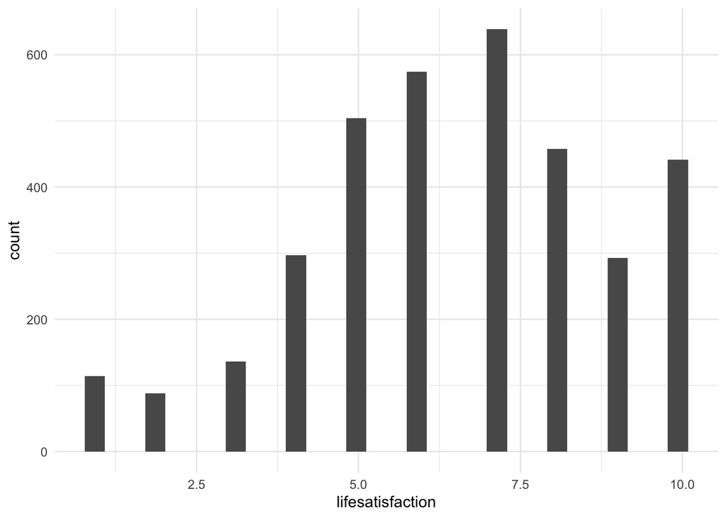

```r
ggplot(data = data, aes(x = lifesatisfaction)) + geom_histogram() + theme_minimal()
```

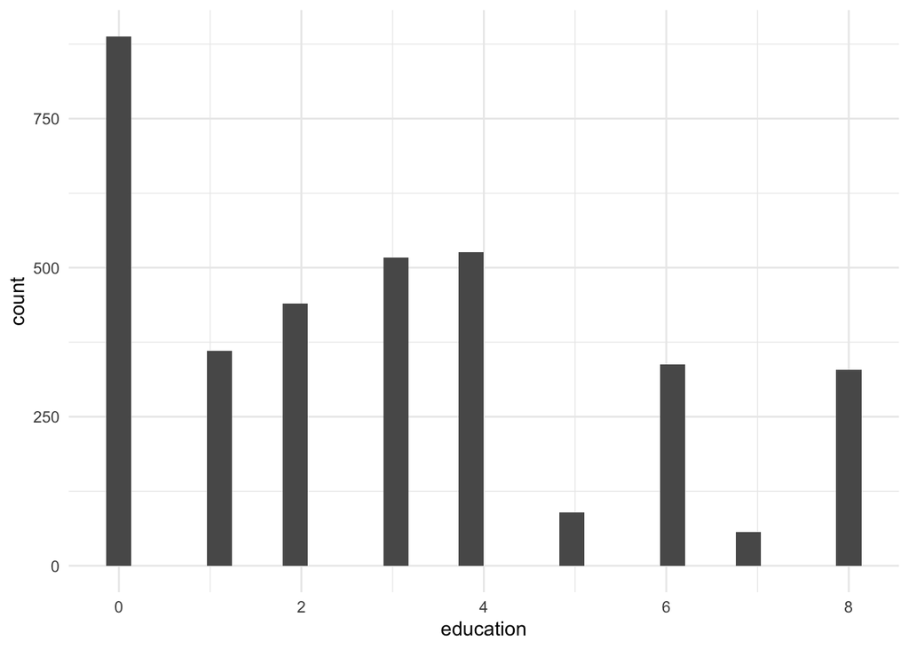

```r
ggplot(data = data, aes(x = education)) + geom_histogram() + theme_minimal()
```

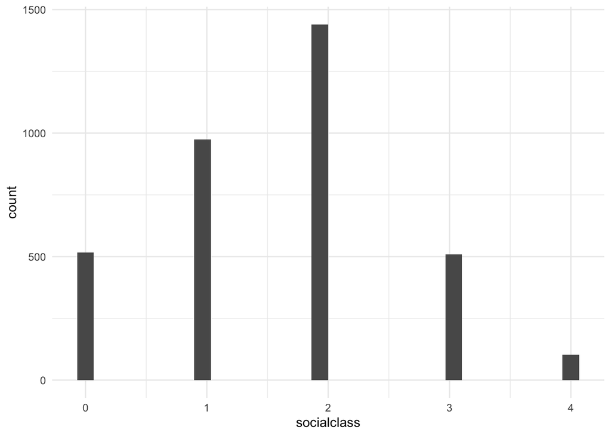

```r
ggplot(data = data, aes(x = socialclass)) + geom_histogram() + theme_minimal()
```

Now running a simple OLS regression.

```r
lm1 <- lm(lifesatisfaction ~ children + religious + employment + socialclass + gender + yearofbirth + education, data)
summary(lm1)
```

```
##
## Call:
## lm(formula = lifesatisfaction ~ children + religious + employment +
##     socialclass + gender + yearofbirth + education, data = data)
##
## Residuals:
##     Min      1Q  Median      3Q     Max
## -6.2847 -1.4497  0.0634  1.5597  4.5157
##
## Coefficients:
##               Estimate Std. Error t value Pr(>|t|)
## (Intercept)  5.4452045  0.1506771  36.138  < 2e-16 ***
## children     0.0143777  0.0263637   0.545    0.586
## religious    0.0349262  0.0212985   1.640    0.101
## employment   0.0357002  0.0855605   0.417    0.677
## socialclass  0.3898810  0.0405050   9.625  < 2e-16 ***
## gender      -0.0305458  0.0825106  -0.370    0.711
## yearofbirth -0.0001893  0.0001234  -1.534    0.125
## education    0.0883405  0.0176218   5.013 5.62e-07 ***
## ---
## Signif. codes:  0 '***' 0.001 '**' 0.01 '*' 0.05 '.' 0.1 ' ' 1
##
## Residual standard error: 2.223 on 3536 degrees of freedom
## Multiple R-squared:  0.0531, Adjusted R-squared:  0.05122
## F-statistic: 28.33 on 7 and 3536 DF,  p-value: < 2.2e-16
```

```r
bptest(lm1)
```

```
##
##  studentized Breusch-Pagan test
##
## data:  lm1
## BP = 66.259, df = 7, p-value = 8.394e-12
```

We can reject the null hypothesis of “homoskedasticity”

```r
coeftest(lm1, vcov = hccm(lm1))
```

```
##
## t test of coefficients:
##
##                Estimate  Std. Error t value  Pr(>|t|)
## (Intercept)  5.44520445  0.15950282 34.1386 < 2.2e-16 ***
## children     0.01437771  0.02753367  0.5222   0.60157
## religious    0.03492617  0.02303753  1.5161   0.12959
## employment   0.03570021  0.08474515  0.4213   0.67359
## socialclass  0.38988098  0.03932791  9.9136 < 2.2e-16 ***
## gender      -0.03054581  0.08465044 -0.3608   0.71824
## yearofbirth -0.00018933  0.00011387 -1.6626   0.09648 .
## education    0.08834048  0.01732526  5.0989 3.595e-07 ***
## ---
## Signif. codes:  0 '***' 0.001 '**' 0.01 '*' 0.05 '.' 0.1 ' ' 1
```

Year of birth became slightly more significant than before.

Let’s add the interaction term of children with yearofbirth.

```r
lm2 <- lm(lifesatisfaction ~ children + religious + employment + socialclass + gender + yearofbirth + education + children*yearofbirth, data)
summary(lm2)
```

```
##
## Call:
## lm(formula = lifesatisfaction ~ children + religious + employment +
##     socialclass + gender + yearofbirth + education + children *
##     yearofbirth, data = data)
##
## Residuals:
##     Min      1Q  Median      3Q     Max
## -6.2918 -1.4394  0.0667  1.5594  4.5137
##
## Coefficients:
##                        Estimate Std. Error t value Pr(>|t|)
## (Intercept)           5.406e+00  1.524e-01  35.479  < 2e-16 ***
## children              2.925e-02  2.772e-02   1.055   0.2913
## religious             3.413e-02  2.130e-02   1.602   0.1091
## employment            3.846e-02  8.555e-02   0.450   0.6530
## socialclass           3.911e-01  4.050e-02   9.658  < 2e-16 ***
## gender               -2.691e-02  8.251e-02  -0.326   0.7443
## yearofbirth           2.290e-04  2.712e-04   0.844   0.3986
## education             8.904e-02  1.762e-02   5.053 4.57e-07 ***
## children:yearofbirth -1.668e-04  9.632e-05  -1.732   0.0833 .
## ---
## Signif. codes:  0 '***' 0.001 '**' 0.01 '*' 0.05 '.' 0.1 ' ' 1
##
## Residual standard error: 2.222 on 3535 degrees of freedom
## Multiple R-squared:  0.0539, Adjusted R-squared:  0.05176
## F-statistic: 25.17 on 8 and 3535 DF,  p-value: < 2.2e-16
```

This is interesting change of signs. Although having children and yearofbirth affect lifesatisfaction positively but for the same yearofbirth having more children affects the lifesatisfaction levels negatively. This implies that having children at a later age or having more children at a less age affects life satisfaction negatively holding other factors constant.

Now let us try the ordinal logit model. Ordinal logit model is used for ordered dependent variable- life satisfaction.

```r
olm1 <- clm(as.factor(lifesatisfaction) ~ children + religious + employment + socialclass + gender + yearofbirth + education, data = data)
summary(olm1)
```

```
## formula:
## as.factor(lifesatisfaction) ~ children + religious + employment + socialclass + gender + yearofbirth + education
## data:    data
##
##  link  threshold nobs logLik   AIC      niter max.grad cond.H
##  logit flexible  3544 -7510.81 15053.62 5(0)  1.31e-07 1.7e+07
##
## Coefficients:
##               Estimate Std. Error z value Pr(>|z|)
## children     6.352e-03  2.093e-02   0.304    0.762
## religious    2.379e-02  1.720e-02   1.383    0.167
## employment  -6.969e-03  6.724e-02  -0.104    0.917
## socialclass  3.034e-01  3.196e-02   9.494  < 2e-16 ***
## gender      -3.328e-02  6.545e-02  -0.508    0.611
## yearofbirth -1.444e-04  9.444e-05  -1.529    0.126
## education    7.285e-02  1.390e-02   5.240 1.61e-07 ***
## ---
## Signif. codes:  0 '***' 0.001 '**' 0.01 '*' 0.05 '.' 0.1 ' ' 1
##
## Threshold coefficients:
##      Estimate Std. Error z value
## 1|2  -2.69158    0.14812 -18.172
## 2|3  -2.08753    0.13495 -15.469
## 3|4  -1.52245    0.12775 -11.917
## 4|5  -0.77813    0.12316  -6.318
## 5|6   0.01889    0.12189   0.155
## 6|7   0.72475    0.12245   5.918
## 7|8   1.50215    0.12420  12.094
## 8|9   2.18923    0.12687  17.256
## 9|10  2.81045    0.13074  21.496
```

For each increase in socialclass level the logit of lifesatisfaction at a higher category vs lower category increases by 0.303 *For each increase in education level the logit of lifesatisfaction at a higher category vs lower category increases by 0.073*

But here the slopes between different levels is different. A jump from 1 to 2 means different than a jump of 5 to 6.

### Mlogit

```r
sort(unique(data$lifesatisfaction))
```

```
##  [1]  1  2  3  4  5  6  7  8  9 10
```

To run mlogit I am changing the levels of lifesatisfaction to 1, 2 and 3.

1-4 will become 1 5-7 will become 2 8-10 will become 3

```r
data$lifesatisfaction[data$lifesatisfaction == 2 | data$lifesatisfaction == 3 | data$lifesatisfaction == 4] = 1
data$lifesatisfaction[data$lifesatisfaction == 5 | data$lifesatisfaction == 6 | data$lifesatisfaction == 7] = 2
data$lifesatisfaction[data$lifesatisfaction == 8 | data$lifesatisfaction == 9 | data$lifesatisfaction == 10] = 3
```

Now that the variable is recoded lets do the Multiple Logistic Regerssion

```r
data1 = mlogit.data(data = data, varying=NULL, choice="lifesatisfaction", shape="wide")
ml1 = mlogit(lifesatisfaction ~ 1 | children + religious + employment + socialclass + gender + yearofbirth + education, data = data1, reflevel="2")
summary(ml1)
```

```
##
## Call:
## mlogit(formula = lifesatisfaction ~ 1 | children + religious +
##     employment + socialclass + gender + yearofbirth + education,
##     data = data1, reflevel = "2", method = "nr")
##
## Frequencies of alternatives:
##       2       1       3
## 0.48448 0.17918 0.33634
##
## nr method
## 5 iterations, 0h:0m:0s
## g'(-H)^-1g = 0.000142
## successive function values within tolerance limits
##
## Coefficients :
##                  Estimate  Std. Error z-value  Pr(>|z|)
## 1:(intercept)  9.2558e-02  1.8288e-01  0.5061 0.6127820
## 3:(intercept) -6.5596e-01  1.5815e-01 -4.1476 3.359e-05 ***
## 1:children     2.5636e-02  3.2333e-02  0.7929 0.4278456
## 3:children     2.4107e-02  2.7372e-02  0.8807 0.3784843
## 1:religious   -1.3772e-01  2.6308e-02 -5.2347 1.653e-07 ***
## 3:religious   -6.4832e-02  2.2003e-02 -2.9465 0.0032137 **
## 1:employment  -4.0901e-01  1.1017e-01 -3.7126 0.0002051 ***
## 3:employment  -2.7128e-01  8.7562e-02 -3.0982 0.0019470 **
## 1:socialclass -1.5915e-01  5.2249e-02 -3.0461 0.0023186 **
## 3:socialclass  3.0799e-01  4.2147e-02  7.3074 2.724e-13 ***
## 1:gender      -1.5465e-01  1.0307e-01 -1.5005 0.1334830
## 3:gender      -1.3873e-01  8.5002e-02 -1.6320 0.1026724
## 1:yearofbirth  6.2882e-05  1.3601e-04  0.4624 0.6438299
## 3:yearofbirth -2.3464e-04  1.4255e-04 -1.6460 0.0997582 .
## 1:education   -6.7192e-02  2.3673e-02 -2.8384 0.0045345 **
## 3:education    4.9068e-02  1.7682e-02  2.7751 0.0055183 **
## ---
## Signif. codes:  0 '***' 0.001 '**' 0.01 '*' 0.05 '.' 0.1 ' ' 1
##
## Log-Likelihood: -3518.4
## McFadden R^2:  0.032065
## Likelihood ratio test : chisq = 233.11 (p.value = < 2.22e-16)
```

For each increase in social class, on average, the logit of being “Not too satisfied” (compared to being “satisfied”) decreases by 0.159 **For each increase in social class, on average, the logit of being “Very satisfied” (compared to being “satisfied”) increases by 0.308***

For each level increase in education, on average, the logit of being “Not too satisfied” (compared to being “satisfied”) decreases by 0.067 **For each level increase in education, on average, the logit of being “Very satisfied” (compared to being “satisfied”) increases by 0.049**

Let’s conduct z-test to check if the slopes are the same or different.

```r
test.socialclass = ((0.15915-0.30799)^2)/(0.052249^2 + 0.042147^2)
test.socialclass %>% print()
```

```
## [1] 4.916053
```

```r
pchisq(test.socialclass, df = 1, lower.tail = FALSE)
```

```
## [1] 0.02660824
```

The value of pchisq is 0.0266 which is <0.05 indicates a strong evidence against the null hypothesis that the slopes are equal.

This means that the 0.15915 != 0.30799.

So |-0.15915| < |0.30799|

```r
test.education = ((0.067192-0.049068)^2)/(0.023673^2 + 0.017682^2)
test.education %>% print()
```

```
## [1] 0.3762374
```

```r
pchisq(test.education, df = 1, lower.tail = FALSE)
```

```
## [1] 0.5396238
```

This means that the 0.067192 ~= 0.049068.

### Mlogt another way

```r
mult1 = multinom(lifesatisfaction ~ children + religious + employment + socialclass + gender + yearofbirth + education, data = data)
summary(mult1)
```

```
## Call:
## multinom(formula = lifesatisfaction ~ children + religious +
##     employment + socialclass + gender + yearofbirth + education,
##     data = data)
##
## Coefficients:
##   (Intercept)     children  religious employment socialclass     gender
## 2 -0.09256042 -0.025636517 0.13771466  0.4090103   0.1591538 0.15465694
## 3 -0.74851696 -0.001530833 0.07288232  0.1377268   0.4671406 0.01593061
##     yearofbirth  education
## 2 -6.287879e-05 0.06719273
## 3 -2.975198e-04 0.11626110
##
## Std. Errors:
##   (Intercept)   children  religious employment socialclass    gender
## 2   0.1828824 0.03233302 0.02630822  0.1101672  0.05224884 0.1030681
## 3   0.1977732 0.03487615 0.02790033  0.1178016  0.05608777 0.1105098
##    yearofbirth  education
## 2 0.0001360058 0.02367287
## 3 0.0001651671 0.02472921
##
## Residual Deviance: 7036.715
## AIC: 7068.715
```

z-test again!

```r
z1 <- summary(mult1)$coefficients/summary(mult1)$standard.errors
z1
```

```
##   (Intercept)   children religious employment socialclass    gender
## 2   -0.506120 -0.7928895  5.234663   3.712632    3.046073 1.5005321
## 3   -3.784724 -0.0438934  2.612238   1.169142    8.328743 0.1441556
##   yearofbirth education
## 2  -0.4623244  2.838385
## 3  -1.8013262  4.701368
```

```r
#options(scipen=999) ## if you want to revert back, use options(scipen=0)
p1 <- (1 - pnorm(abs(z1), 0, 1))*2
p1 %>% print()
```

```
##    (Intercept)  children    religious   employment socialclass    gender
## 2 0.6127724086 0.4278422 1.652858e-07 0.0002051147 0.002318515 0.1334766
## 3 0.0001538796 0.9649894 8.995155e-03 0.2423464722 0.000000000 0.8853776
##   yearofbirth    education
## 2  0.64384874 4.534245e-03
## 3  0.07165149 2.584240e-06
```

```r
# data frame of values to use for predictions
data.predict <- expand.grid(
  education = 1:9, #vary education from 1 to 6
  yearofbirth = 30,  #fix age at the mean
  children = 0,
  religious = 0,
  employment = 1,
  socialclass = 2,
  gender = 1)
```

Let’s predict the lifesatisfaction when we change education. According to our analysis increase in education level should increase lifesatisfaction.

```r
preds.lifesatisfaction <- data.frame(
  education = data.predict$education, # education
  predict(mult1, newdata = data.predict, type = "probs", se = TRUE)) # predicted probabilities

preds.lifesatisfaction %>% print()
```

```
##   education        X1        X2        X3
## 1         1 0.2035022 0.4783762 0.3181216
## 2         2 0.1897511 0.4770526 0.3331962
## 3         3 0.1766383 0.4749504 0.3484113
## 4         4 0.1641673 0.4720973 0.3637354
## 5         5 0.1523374 0.4685250 0.3791376
## 6         6 0.1411437 0.4642686 0.3945877
## 7         7 0.1305779 0.4593660 0.4100561
## 8         8 0.1206282 0.4538575 0.4255142
## 9         9 0.1112801 0.4477851 0.4409347
```

Here when the education level is 1 then the probability of life satisfaction being level 3 (very satisfied) is 0.3181216 and as the education level increases the probability of life satisfaction being level 3 (very satisfied) keeps increasing and is 0.4409347 when education level is 9.

I will predict the life satisfaction by varying the social class as well.

```r
# data frame of values to use for predictions
data.predict1 <- expand.grid(
  education = 5, #fix at 5
  yearofbirth = 30,  #fix age at the mean
  children = 0,
  religious = 0,
  employment = 1,
  socialclass = 0:4, #varying from 0 to level 4
  gender = 1)
```

Let’s predict the lifesatisfaction when we change social class According to our analysis increase in social class level should increase lifesatisfaction.

```r
preds.lifesatisfaction1 <- data.frame(
  socialclass = data.predict1$socialclass, # socialclass
  predict(mult1, newdata = data.predict1, type = "probs", se = TRUE)) # predicted probabilities

preds.lifesatisfaction1 %>% print()
```

```
##   socialclass         X1        X2        X3
## 1           0 0.23725471 0.5307645 0.2319808
## 2           1 0.19293802 0.5060862 0.3009758
## 3           2 0.15233739 0.4685250 0.3791376
## 4           3 0.11659270 0.4204528 0.4629545
## 5           4 0.08648086 0.3656667 0.5478524
```

This prediction also agrees with our hypothesis. When social class is 0 the probabolity of saying that a person is very satisfied with life is 0.2319808 and the highest probability is of saying that they are satisfied (the medium level) and when social class increases to 4 the same probability increases to 0.5478524.

### Sanity checks

```r
table(data$lifesatisfaction[data$socialclass == 0]) %>% print()
```

```
##
##   1   2   3
## 142 270 104
```

```r
table(data$lifesatisfaction[data$socialclass == 4]) %>% print()## sanity check, small-medium-large in precentages
```

```
##
##  1  2  3
##  5 40 58
```

### Predicting other models as well (Sanity checks)

Here I am doing the prediction using the linear regression mmodel.

```r
predict(lm1, data.frame(education = 2, yearofbirth = 30, children = 0, religious = 0, employment = 1, socialclass = 3, gender = 0)) %>% print()
```

```
##        1
## 6.821549
```

```r
#increasing the education level by 1
predict(lm1, data.frame(education = 3, yearofbirth = 30, children = 0, religious = 0, employment = 1, socialclass = 3, gender = 0)) %>% print()
```

```
##        1
## 6.909889
```

This model also shows that the level of life satisfaction has increased from 6.8 to 6.9 when education level was increased from 2 to 3.

Here I am doing the prediction using the multinomial logit model. This is just to see the impact changing gender is having on the life satisfaction level. Females (gender = 1) have lower level of satisfaction than males keeping everything else constant in the model.

```r
predict(mult1, data.frame(education = 2, yearofbirth = 30, children = 0, religious = 0, employment = 1, socialclass = 3, gender = 1)) %>% print()
```

```
## [1] 2
## Levels: 1 2 3
```

```r
predict(mult1, data.frame(education = 2, yearofbirth = 30, children = 0, religious = 0, employment = 1, socialclass = 3, gender = 0)) %>% print()
```

```
## [1] 3
## Levels: 1 2 3
```

Lets do the same thing for females by varying their education levels.

```r
predict(mult1, data.frame(education = 2, yearofbirth = 30, children = 0, religious = 0, employment = 1, socialclass = 3, gender = 1)) %>% print()
```

```
## [1] 2
## Levels: 1 2 3
```

```r
predict(mult1, data.frame(education = 4, yearofbirth = 30, children = 0, religious = 0, employment = 1, socialclass = 3, gender = 1)) %>% print()
```

```
## [1] 3
## Levels: 1 2 3
```

Increasing the education by two levels and keeping everything else constant increased the level of happiness from 2 to 3.